# Assignment 9

Jiaming Xu

## Q1: Loading data

```r
library(tidyverse)
url = "https://data.sfgov.org/api/views/rkru-6vcg/rows.csv?accessType=DOWNLOAD"
df <- read_csv(url)
```

There are 12 columns. Two are numerical.

```r
glimpse(df)
```

```
Rows: 46,670
Columns: 12
$ `Activity Period`             <dbl> 200507, 200507, 200507, 200507, 200507, 200…
$ `Operating Airline`           <chr> "ATA Airlines", "ATA Airlines", "ATA Airlin…
$ `Operating Airline IATA Code` <chr> "TZ", "TZ", "TZ", "AC", "AC", "CA", "CA", "…
$ `Published Airline`           <chr> "ATA Airlines", "ATA Airlines", "ATA Airlin…
$ `Published Airline IATA Code` <chr> "TZ", "TZ", "TZ", "AC", "AC", "CA", "CA", "…
$ `GEO Summary`                 <chr> "Domestic", "Domestic", "Domestic", "Intern…
$ `GEO Region`                  <chr> "US", "US", "US", "Canada", "Canada", "Asia…
$ `Activity Type Code`          <chr> "Deplaned", "Enplaned", "Thru / Transit", "…
$ `Price Category Code`         <chr> "Low Fare", "Low Fare", "Low Fare", "Other"…
$ Terminal                      <chr> "Terminal 1", "Terminal 1", "Terminal 1", "…
$ `Boarding Area`               <chr> "B", "B", "B", "B", "B", "G", "G", "A", "A"…
$ `Passenger Count`             <dbl> 27271, 29131, 5415, 35156, 34090, 6263, 550…
```

```r
summary(df)
```

```
 Activity Period  Operating Airline  Operating Airline IATA Code
 Min.   :200507   Length:46670       Length:46670
 1st Qu.:200908   Class :character   Class :character
 Median :201311   Mode  :character   Mode  :character
 Mean   :201323
 3rd Qu.:201709
 Max.   :202106
 Published Airline  Published Airline IATA Code GEO Summary
 Length:46670       Length:46670                Length:46670
 Class :character   Class :character            Class :character
 Mode  :character   Mode  :character            Mode  :character



  GEO Region        Activity Type Code Price Category Code   Terminal
 Length:46670       Length:46670       Length:46670        Length:46670
 Class :character   Class :character   Class :character    Class :character
 Mode  :character   Mode  :character   Mode  :character    Mode  :character



 Boarding Area      Passenger Count
 Length:46670       Min.   :     1
 Class :character   1st Qu.:  4796
 Mode  :character   Median :  8796
                    Mean   : 28853
                    3rd Qu.: 19755
                    Max.   :659837
```

## Q2: Filter domestic flights in March every year.

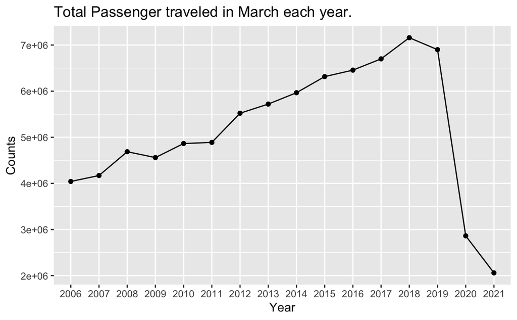

```r
df_2 <- df %>%
  filter(`GEO Region` == 'US', ) %>%
  mutate(Date = as.Date(paste0(`Activity Period`, "01"), format="%Y%m%d")) %>%
  mutate(Year = format(Date, "%Y"), Month = format(Date, "%b")) %>%
  filter(Month == "Mar") %>%
  group_by(Year) %>%
  summarise( Total_passenger = sum(`Passenger Count`))
df_2 %>%
  ggplot( aes(x = Year, y = Total_passenger, group = 1)) +
  geom_point()+
  geom_line() +
  labs( y = "Counts", title = "Total Passenger traveled in March each year.")
```

```r
NA
```

From the figure above we can see the number of passenger in 2020 and 2021 drop significantly compared to 2019 since the pademic hit the U.S. in Feb, 2020, and lock down the country in March, 2020.

## Q3: Simple movement for 2019 prediction

```r
sprintf("Predicted number of passengers in March 2019 using simple average model among 2016-2018 is %.0f, real number is %.0f, with error %.2f%%.", sim_2019, real_2019, abs(sim_2019-real_2019)/sim_2019*100)
```

```
[1] "Predicted number of passengers in March 2019 using simple average model among 2016-2018 is 6771607, real number is 6899726, with error 1.89%."
```

Our prediction is smaller than real number of passengers, but with only 1.89% error. This indicate that our model is pretty reliable for 2019.

## Q4: Weighted prediction for 2019

```r
prew_2019 <- sum(df_2[11:13,2] * c(3,5,7))/sum(c(3,5,7))
sprintf("Predicted number of passengers in March 2019 using weighted model with factors 3,5,7 among 2016-2018 is %.0f, real number is %.0f, with error %.2f%%.", prew_2019, real_2019, abs(prew_2019-real_2019)/prew_2019*100)
```

```
[1] "Predicted number of passengers in March 2019 using weighted model with factors 3,5,7 among 2016-2018 is 6865349, real number is 6899726, with error 0.50%."
```

Now we can see the error is decreased to 0.5% using weighted moving average prediction model, which is better than simple moving average result.

## Q5: Exponential smoothing prediction for 2019

```r
preexp <- df_2
preexp$es <- 0
preexp$error <- 0
preexp$es[1] <- df_2$Total_passenger[1]
alpha <- 0.7

for (i in 2:nrow(preexp)) {
  preexp$es[i] <- preexp$es[i-1] + (alpha * preexp$error[i-1])
  preexp$error[i] <-  preexp$Total_passenger[i] - preexp$es[i]
}
preexp$perror <- abs(preexp$es - preexp$Total_passenger)*100/preexp$es
preexp
```

| Year | Total_passenger | es | error | perror |
| --- | --- | --- | --- | --- |
| 2006 | 4042422 | 4042422 | 0.00 | 0.0000000 |
| 2007 | 4170612 | 4042422 | 128190.00 | 3.1711187 |
| 2008 | 4687274 | 4132155 | 555119.00 | 13.4341282 |
| 2009 | 4559998 | 4520738 | 39259.70 | 0.8684356 |
| 2010 | 4864702 | 4548220 | 316481.91 | 6.9583684 |
| 2011 | 4888920 | 4769757 | 119162.57 | 2.4982942 |
| 2012 | 5521460 | 4853171 | 668288.77 | 13.7701462 |
| 2013 | 5720054 | 5320973 | 399080.63 | 7.5001434 |
| 2014 | 5965800 | 5600330 | 365470.19 | 6.5258690 |
| 2015 | 6315394 | 5856159 | 459235.06 | 7.8419159 |

[output cut: 6 more lines]

From the results above we can see the prediction with alpha = 0.7 is 6991736, 92009 more than real value, with 1.316% error. This prediction is not better than weighted moving average method.

## Q6: Linear regression prediction for 2019

```r
df_2 <- df_2[1:13,] %>% mutate(Year = as.numeric(Year))
lm_model <- lm(Total_passenger ~ Year, data = df_2[1:13,])
lm_model
```

```
Call:
lm(formula = Total_passenger ~ Year, data = df_2[1:13, ])

Coefficients:
(Intercept)         Year
 -511021470       256703
```

The formula is count = 256703 * Year - 511021470

```r
sprintf("Here we can see the predicted values for 2019 and 2020 are %.0f, %.0f, with error%% %.3f %% and %.3f %%, respectively.", prel_2019, prel_2020, abs(prel_2019-df_2[14,2])*100/prel_2019, abs(prel_2020-df_2[15,2])*100/prel_2020)
```

[output not shown]

Not surprisingly, the prediction for 2019 is acceptable, but not for 2020 prediction.

## Q7: Calculate MSE for Q5 & Q6.

### MSE for exponential model:

```r
preexp[3:13,] %>%
  mutate(SR = error^2) %>%
  pull(SR) %>%
  mean()
```

```
[1] 169954477978
```

### MSE for linear model:

```r
lm_model_prediction <- lm_model$coeff[2] * df_2[,1] + lm_model$coeff[1]
sum((lm_model_prediction[3:13,] - df_2[3:13,2])^2)/nrow(df_2[3:13,])
```

```
[1] 20628650932
```